# **MATH 237 Project #1**

**Team Members:**  
Sean Mitani  
Preston Nguyen

**Research Questions:**  
Through diving into this dataset, there were interests that emerged through the data. For the research questions of this project, we asked:

1. "How does a house's lot size in square feet directly affect its sale price?"
2. "Does the year during which a house was constructed have a significant impact on its sale price?"
3. "Is there an association between a house's masonry veneer area in square feet and its sale price?"
4. "Could there be a connection between a house's ground living area in square feet and its sale price?"

**Significance**  
There were two primary reasons explaining why these questions were important points to explore. First, this data could provide crucial insight to which variables were the most explanatory in determining the price of a house. Second, the description and prediction of housing prices can be of interest to other people, like investors, social scientists, and general readers.

In researching the determinants of housing in Ames, Iowa, it is hard to discern which variables have the most explanatory power in explaining the price by just eyeballing the large amounts of data. Regression models represent one attempt to aggregate large amounts of data to predict a particular characteristic. Although it is a simple model, it is a very significant one. Crucial insights can be provided with just a simple regression model, where investigating how simple variables like lot size, year, masonry veneer area, and housing ground living area can impact the price of a house. Whether or not it is comparing the magnitude of influence or attempting to see how well these predictions line up with reality, these questions serve as a stepping stone towards investigating larger issues.

Furthermore, beyond the constraints of this model, the connection between housing price and a selection of variables may be of crucial from a descriptive and inferential standpoint. When catering to a general audience, those who want to record the economics of Ames, Iowa may turn to the housing dataset in order to get a sense of the living standards. Descriptive indicators like the mean housing cost or the different quartile points may allow for people to report details on this area. Social scientists may want to compare this data to other facts about this area. For example, investigating things like housing and race may allow such a dataset to be compared with other datasets. Investors may want to infer the price of housing based on current events and factors that might make this area profitable or unprofitable. Beyond this model, such research questions can allow bigger audiences to grasp a sense of this place from a descriptive and inferential standpoint.

# **Part 1 – Setting Up the Dataset**

First, we should set the stage for our project by looking at the dataset dictionary in more detail. In order to accomplish this, we need to import particular libraries, connect to our Google Drive, and ensure that we are connected with the Ames housing dataset.

```python
# We should import the libraries that we need for our project.
import pandas as pd
import numpy as np
import matplotlib.pyplot as plt
import seaborn as sns
from sklearn.preprocessing import StandardScaler, LabelEncoder

# We will also add a few other libraries.
from sklearn.linear_model import LinearRegression
from sklearn.model_selection import train_test_split
from sklearn.metrics import r2_score, mean_squared_error
```

```python
# Here, I will connect this file to my Google Drive account.
from google.colab import drive
drive.mount('/content/drive')
print("Your Google Drive account has now been connected.")
```

```
Your Google Drive account has now been connected.
```

```python
# We will load the Ames Housing dataset into this notebook.
housing = pd.read_csv('/content/drive/MyDrive/Foundations_of_Data_Science/Datasets/ames-housing-train.csv')
```

```python
# We will view each variable's data type object and its null value.
housing.info()
```

```
<class 'pandas.core.frame.DataFrame'>
RangeIndex: 1460 entries, 0 to 1459
Data columns (total 81 columns):
 #   Column         Non-Null Count  Dtype
---  ------         --------------  -----
 0   Id             1460 non-null   int64
 1   MSSubClass     1460 non-null   int64
 2   MSZoning       1460 non-null   object
 3   LotFrontage    1201 non-null   float64
 4   LotArea        1460 non-null   int64
 5   Street         1460 non-null   object
 6   Alley          91 non-null     object
 7   LotShape       1460 non-null   object
 8   LandContour    1460 non-null   object
 9   Utilities      1460 non-null   object
```

[output cut: 73 more lines]

# **Part 2 – Handling the Missing Data**

Now that the dataset is ready to work on, we should check it for any missing values and deal with them accordingly.

```python
# Since we are only focusing on five variables in total, we should remove the
# remaining variables.
df = pd.DataFrame(housing)
housing_data = df[['LotArea', 'YearBuilt', 'MasVnrArea', 'GrLivArea','SalePrice']]
print(housing_data)
```

```
      LotArea  YearBuilt  MasVnrArea  GrLivArea  SalePrice
0        8450       2003       196.0       1710     208500
1        9600       1976         0.0       1262     181500
2       11250       2001       162.0       1786     223500
3        9550       1915         0.0       1717     140000
4       14260       2000       350.0       2198     250000
...       ...        ...         ...        ...        ...
1455     7917       1999         0.0       1647     175000
1456    13175       1978       119.0       2073     210000
1457     9042       1941         0.0       2340     266500
1458     9717       1950         0.0       1078     142125
1459     9937       1965         0.0       1256     147500

[1460 rows x 5 columns]
```

```python
# Next, we will take a look at these variables to search for any missing data.
print("Missing Values of Each Variable:")
missing_values = housing_data.isnull().sum()
print(missing_values)
```

```
Missing Values of Each Variable:
LotArea       0
YearBuilt     0
MasVnrArea    8
GrLivArea     0
SalePrice     0
dtype: int64
```

```python
# We will print out the number of missing values, complete cases, and cases
# altogether.
complete_cases = len(housing_data.dropna())
print(f"Total Number of Missing Values: {missing_values.sum()}")
print(f"Total Number of Complete Cases: {complete_cases}")
print(f"Total Number of Cases: {len(housing_data)}")
```

```
Total Number of Missing Values: 8
Total Number of Complete Cases: 1452
Total Number of Cases: 1460
```

```python
# More specifically, we can display a few instances where the missing data
# occurs.
print("\nThe First 5 Rows with Missing Values")
print(housing_data[housing_data.isnull().any(axis = 1)].head())
```

```
The First 5 Rows with Missing Values
     LotArea  YearBuilt  MasVnrArea  GrLivArea  SalePrice
234     7851       2002         NaN       1960     216500
529    32668       1957         NaN       2515     200624
650     8125       2007         NaN       1665     205950
936    10083       2003         NaN       1200     184900
973    11639       2007         NaN       1428     182000
```

**Conclusions:**

- The area of a house's masonry veneer cannot be identified if the house does not even have a masonry veneer in the first place. Therefore, this variable is missing not at random (MNAR) because the missing values are dependent on whether the house has a masonry veneer or not.
- We will avoid imputation methods because it is insignificant. In other words, it would not make sense to form an educated guess if only 8 samples are missing.
- Thus, since less than 5% of the data is missing, we will use listwise deletion by removing all 8 samples that do not have a masonry veneer area listed.

```python
# Before we begin, we should create a copy of the dataset to prevent the
# original one from being overwritten.
housing_complete = housing_data.dropna()
print("Listwise Deletion Results")
print(f"Old Dataset: {len(housing_data)} houses in total")
print(f"New Dataset: {len(housing_complete)} houses in total")
print(f"Houses Lost: {len(housing_data) - len(housing_complete)} houses ({(len(housing_data) - len(housing_complete))/len(housing_data) * 100:.1f}%)")

# However, we should make sure that our sample is still representative of the
# population.
print(f"\nHouses Distribution Comparison")
print(f"Before Listwise Deletion:")
old_houses = housing_data['MasVnrArea'].value_counts(normalize = True).round(3)
print(old_houses)
print(f"\nAfter Listwise Deletion:")
new_houses = housing_complete['MasVnrArea'].value_counts(normalize = True).round(3)
print(new_houses)
```

```
Listwise Deletion Results
Old Dataset: 1460 houses in total
New Dataset: 1452 houses in total
Houses Lost: 8 houses (0.5%)

Houses Distribution Comparison
Before Listwise Deletion:
MasVnrArea
0.0      0.593
108.0    0.006
72.0     0.006
180.0    0.006
16.0     0.005
         ...
426.0    0.001
96.0     0.001
438.0    0.001
194.0    0.001
119.0    0.001
Name: proportion, Length: 327, dtype: float64

After Listwise Deletion:
MasVnrArea
0.0      0.593
108.0    0.006
72.0     0.006
180.0    0.006
16.0     0.005
         ...
426.0    0.001
96.0     0.001
438.0    0.001
194.0    0.001
119.0    0.001
Name: proportion, Length: 327, dtype: float64
```

# **Part 3 – Performing Feature Engineering**

Once the missing values have been taken care of, we can perform some feature engineering on both our numerical and categorical variables.

```python
# To begin with, we should create another copy of our dataset.
housing_enhanced = housing.copy()
```

```python
# For our first two numerical variables, we can use ratio features to compare
# the house's lot size in square feet and the year in which it was built with
# its sale price.
housing_enhanced['Price_to_Size_Ratio'] = housing_enhanced['SalePrice'] / housing_enhanced['LotArea']
housing_enhanced['Price_to_Year_Ratio'] = housing_enhanced['SalePrice'] / housing_enhanced['YearBuilt']
```

```python
# For our third numerical variable, we can use binning to split the house's
# masonry veneer area in square feet into different ranges.
housing_enhanced['Masonry_Veneer_Area_Categories'] = pd.cut(housing_enhanced['MasVnrArea'],
                                            bins = [0, 1, 250, 500, 750, 1000, 1250],
                                            labels = ['None', 'Very Small', 'Small', 'Medium', 'Large', 'Very Large'])
```

```python
# For our fourth numerical variable, we can also use binning to split the
# house's ground living area in square feet into similar categories.
housing_enhanced['Ground_Living_Area_Categories'] = pd.cut(housing_enhanced['GrLivArea'],
                                                         bins = [1, 900, 1800, 2700, 3600, 4500],
                                                         labels = ['Very Small', 'Small', 'Medium', 'Large', 'Very Large'])
```

```python
# For our fifth numerical variable, we can use binning again to separate the
# house's sale prices into appropriate intervals.
housing_enhanced['Sale_Price_Categories'] = pd.cut(housing_enhanced['SalePrice'],
                                       bins = [0, 250000, 500000, 750000],
                                       labels = ['Entry-Level', 'Mid-Range', 'Luxury'])
```

```python
# Afterward, we can show all of these features for the first five samples with a
# table.
housing_enhanced[['Price_to_Size_Ratio', 'Price_to_Year_Ratio', 'MasVnrArea', 'Masonry_Veneer_Area_Categories', 'GrLivArea', 'Ground_Living_Area_Categories', 'Sale_Price_Categories']].head()
```

|  | Price_to_Size_Ratio | Price_to_Year_Ratio | MasVnrArea | Masonry_Veneer_Area_Categories | GrLivArea | Ground_Living_Area_Categories | Sale_Price_Categories |
| --- | --- | --- | --- | --- | --- | --- | --- |
| 0 | 24.674556 | 104.093859 | 196.0 | Very Small | 1710 | Small | Entry-Level |
| 1 | 18.906250 | 91.852227 | 0.0 | NaN | 1262 | Small | Entry-Level |
| 2 | 19.866667 | 111.694153 | 162.0 | Very Small | 1786 | Small | Entry-Level |
| 3 | 14.659686 | 73.107050 | 0.0 | NaN | 1717 | Small | Entry-Level |
| 4 | 17.531557 | 125.000000 | 350.0 | Small | 2198 | Medium | Entry-Level |

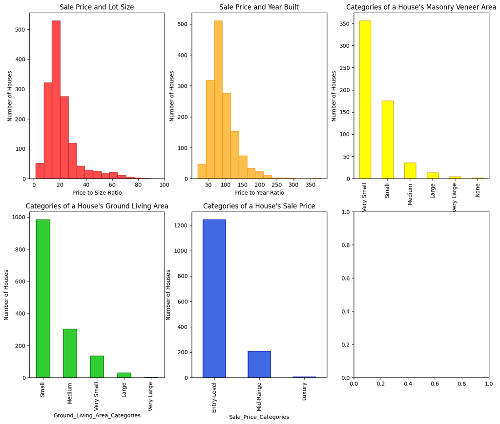

```python
# Now that we have finished our feature engineering, we can visualize all of
# them side-by-side.
fig, axes = plt.subplots(2, 3, figsize = (15, 12))

# 1. As the first graph, we will assemble a histogram with red bars to convey
#    the ratio between the houses' sale prices and their lot sizes.
axes[0, 0].hist(housing_enhanced['Price_to_Size_Ratio'], bins = 15,
                color = 'red', alpha = 0.7, edgecolor = 'brown')
axes[0, 0].set_title("Sale Price and Lot Size")
axes[0, 0].set_xlabel('Price to Size Ratio')
axes[0, 0].set_ylabel('Number of Houses')

# 2. As the second graph, we will build a histogram with orange bars to display
#    the ratio between the houses' sale prices and the years in which they were
#    built.
axes[0, 1].hist(housing_enhanced['Price_to_Year_Ratio'], bins = 15,
                color = 'orange', alpha = 0.7, edgecolor = 'darkorange')
axes[0, 1].set_title("Sale Price and Year Built")
axes[0, 1].set_xlabel('Price to Year Ratio')
axes[0, 1].set_ylabel('Number of Houses')

# 3. As the third graph, we will create a histogram with yellow bars to
#    emphasize the different categories of the houses' masonry veneer areas.
housing_enhanced['Masonry_Veneer_Area_Categories'].value_counts().plot(kind = 'bar',
                                                                       ax = axes[0, 2],
                                                                       color = 'yellow',
                                                                       edgecolor = 'goldenrod')
axes[0, 2].set_title("Categories of a House's Masonry Veneer Area")
axes[0, 2].set_ylabel('Number of Houses')

# 4. As the fourth graph, we will generate a histogram with green bars to
#    highlight the many categories of the houses' ground living areas.
housing_enhanced['Ground_Living_Area_Categories'].value_counts().plot(kind = 'bar',
                                                                      ax = axes[1, 0],
                                                                      color = 'limegreen',
                                                                      edgecolor = 'darkgreen')
axes[1, 0].set_title("Categories of a House's Ground Living Area")
axes[1, 0].set_ylabel('Number of Houses')

# 5. As the fifth graph, we will make a histogram with blue bars to point out
#    the various categories of the houses' sale prices.
housing_enhanced['Sale_Price_Categories'].value_counts().plot(kind = 'bar',
                                                              ax = axes[1, 1],
                                                              color = 'royalblue',
                                                              edgecolor = 'mediumblue')
axes[1, 1].set_title("Categories of a House's Sale Price")
axes[1, 1].set_ylabel('Number of Houses')
```

# **Part 4 – Visualizing the Data**

Then, we chose to visually display all four variables by creating both histograms and scatterplots.

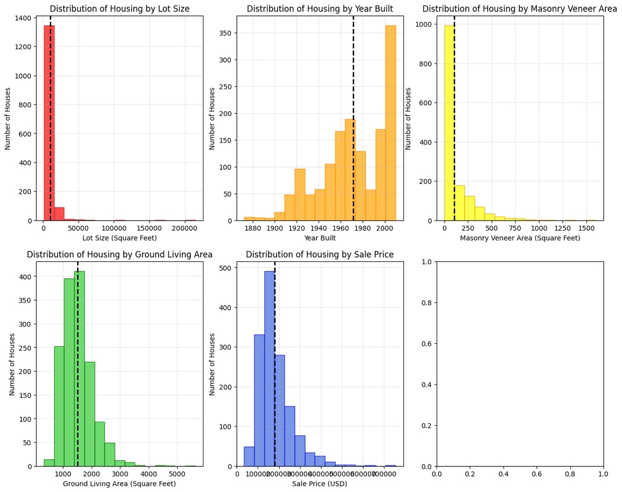

```python
# We will start with histograms for the house's lot size, the year in which it
# was built, its masonry veneer area, its ground living area, and its sale
# price.
fig, axes = plt.subplots(2, 3, figsize = (15, 12))

# 1. As the first graph, we will assemble another histogram with red bars to
#    convey the distribution of the houses based on their lot sizes.
axes[0, 0].hist(housing['LotArea'], bins = 15, color = 'red', alpha = 0.7, edgecolor = 'brown')
axes[0, 0].axvline(housing['LotArea'].mean(), color = 'black', linestyle = '--', linewidth = 2)
axes[0, 0].set_title('Distribution of Housing by Lot Size')
axes[0, 0].set_xlabel('Lot Size (Square Feet)')
axes[0, 0].set_ylabel('Number of Houses')
axes[0, 0].grid(True, alpha = 0.3)

# 2. As the second graph, we will build another histogram with orange bars to
#    display the distribution of the houses based on the years in which they
#    were built.
axes[0, 1].hist(housing['YearBuilt'], bins = 15, color = 'orange', alpha = 0.7, edgecolor = 'darkorange')
axes[0, 1].axvline(housing['YearBuilt'].mean(), color = 'black', linestyle = '--', linewidth = 2)
axes[0, 1].set_title('Distribution of Housing by Year Built')
axes[0, 1].set_xlabel('Year Built')
axes[0, 1].set_ylabel('Number of Houses')
axes[0, 1].grid(True, alpha = 0.3)

# 3. As the third graph, we will create another histogram with yellow bars to
#    present the distribution of the houses based on their masonry veneer areas.
axes[0, 2].hist(housing['MasVnrArea'], bins = 15, color = 'yellow', alpha = 0.7, edgecolor = 'goldenrod')
axes[0, 2].axvline(housing['MasVnrArea'].mean(), color = 'black', linestyle = '--', linewidth = 2)
axes[0, 2].set_title('Distribution of Housing by Masonry Veneer Area')
axes[0, 2].set_xlabel('Masonry Veneer Area (Square Feet)')
axes[0, 2].set_ylabel('Number of Houses')
axes[0, 2].grid(True, alpha = 0.3)

# 4. As the fourth graph, we will generate another histogram with green bars to
#    show the distribution of the houses based on their ground living areas.
axes[1, 0].hist(housing['GrLivArea'], bins = 15, color = 'limegreen', alpha = 0.7, edgecolor = 'darkgreen')
axes[1, 0].axvline(housing['GrLivArea'].mean(), color = 'black', linestyle = '--', linewidth = 2)
axes[1, 0].set_title('Distribution of Housing by Ground Living Area')
axes[1, 0].set_xlabel('Ground Living Area (Square Feet)')
axes[1, 0].set_ylabel('Number of Houses')
axes[1, 0].grid(True, alpha = 0.3)

# 5. As the fifth graph, we will make another histogram with blue bars to
#    visualize the distribution of the houses based on their sale prices.
axes[1, 1].hist(housing['SalePrice'], bins = 15, color = 'royalblue', alpha = 0.7, edgecolor = 'mediumblue')
axes[1, 1].axvline(housing['SalePrice'].mean(), color = 'black', linestyle = '--', linewidth = 2)
axes[1, 1].set_title('Distribution of Housing by Sale Price')
axes[1, 1].set_xlabel('Sale Price (USD)')
axes[1, 1].set_ylabel('Number of Houses')
axes[1, 1].grid(True, alpha = 0.3)
```

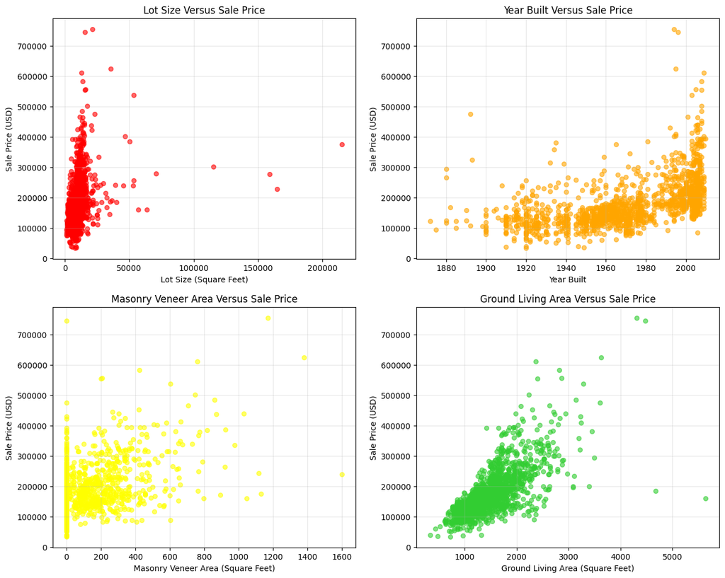

```python
# Afterward, we will continue with scatterplots to show the relationships
# between the house's lot size, the year in which it was built, its masonry
# veneer area, and its ground living area against its sale price.
fig, axes = plt.subplots(2, 2, figsize = (15, 12))

# 1. As the first graph, we will assemble a scatterplot with red points to
#    convey the relationship between the houses' lot sizes and their sale
#    prices.
axes[0, 0].scatter(housing['LotArea'], housing['SalePrice'], color = 'red', alpha = 0.6, s = 30)
axes[0, 0].set_title('Lot Size Versus Sale Price')
axes[0, 0].set_xlabel('Lot Size (Square Feet)')
axes[0, 0].set_ylabel('Sale Price (USD)')
axes[0, 0].grid(True, alpha = 0.3)

# 2. As the second graph, we will build a scatterplot with orange points to
#    display the relationship between the houses' years in which they were built
#    and their sale prices.
axes[0, 1].scatter(housing['YearBuilt'], housing['SalePrice'], color = 'orange', alpha = 0.6, s = 30)
axes[0, 1].set_title('Year Built Versus Sale Price')
axes[0, 1].set_xlabel('Year Built')
axes[0, 1].set_ylabel('Sale Price (USD)')
axes[0, 1].grid(True, alpha = 0.3)

# 3. As the third graph, we will create a scatterplot with yellow points to
#    present the relationship between the houses' masonry veneer areas and their
#    sale prices.
axes[1, 0].scatter(housing['MasVnrArea'], housing['SalePrice'], color = 'yellow', alpha = 0.6, s = 30)
axes[1, 0].set_title('Masonry Veneer Area Versus Sale Price')
axes[1, 0].set_xlabel('Masonry Veneer Area (Square Feet)')
axes[1, 0].set_ylabel('Sale Price (USD)')
axes[1, 0].grid(True, alpha = 0.3)

# 4. As the fourth graph, we will generate a scatterplot with green points to
#    show the relationship between the houses' ground living areas and their
#    sale prices.
axes[1, 1].scatter(housing['GrLivArea'], housing['SalePrice'], color = 'limegreen', alpha = 0.6, s = 30)
axes[1, 1].set_title('Ground Living Area Versus Sale Price')
axes[1, 1].set_xlabel('Ground Living Area (Square Feet)')
axes[1, 1].set_ylabel('Sale Price (USD)')
axes[1, 1].grid(True, alpha = 0.3)
```

**Observations:**

- For the first scatterplot in red, there does not appear to be any correlation between the house's lot size and its sale price. Furthermore, most of the houses seem to cluster in having a smaller housing lot under 50,000 square feet.
- But for the second scatterplot in orange, there seems to be a slightly positive correlation between the year in which a house was built and its sale price. In other words, the houses with less recent years will be sold for lower prices whereas those with more recent years will be sold for higher prices. Although this is not linear, we can see this visibly as it slowly trends upward.
- As for the third scatterplot in yellow, there is not much of a correlation here either between the house's masonry veneer area and its sale price. However, there is a cluster of houses that have small masonry veneer areas and low sale prices.
- In the fourth scatterplot in green, there is a visible positive correlation between the house's ground living area and its sale price. As the house's ground living area increases in square feet, so does its sale price. Likewise, its sale price decreases as its ground living area becomes smaller.
- Noticably, the scatter plots indicate some outliers. For example, in the fourth scatter plot, there are some larger houses that are larger than 4,000 square feet that are cheaper than $200,000. These outliers are identified by being away from the clusters of data.

# **Part 5 – Conducting Multiple Linear Regression**

- The four features (x) that we will be exploring include the house's lot size, the year during which it was built, its masonry veneer area, and its ground living area.
- Meanwhile, the target (y) that we will focus on is the house's sale price.
- So, our equation for this type of linear regression will look like: $$Predicted Sale Price = b_0() + b_1(LotArea) + b_2(YearBuilt) + b_3(MasVnrArea) + b_4(GrLivArea),$$ where $$b_0, b_1, b_2, b_3, and b_4$$ are the parameters for this model.

```python
# We will assign the appropriate variables that we discussed above to our x and
# y parts.
x = housing_complete[['LotArea', 'YearBuilt', 'MasVnrArea', 'GrLivArea']]
y = housing_complete['SalePrice']
```

```python
# We will split the data into the training and test sets using the standard
# 80-20 split.
X_train, X_test, y_train, y_test = train_test_split(x, y, test_size = 0.2, random_state = 10)

print(f"Training set size: {len(X_train)} samples")
print(f"Test set size: {len(X_test)} samples")

y_train.info()
```

```
Training set size: 1161 samples
Test set size: 291 samples
<class 'pandas.core.series.Series'>
Index: 1161 entries, 1058 to 1297
Series name: SalePrice
Non-Null Count  Dtype
--------------  -----
1161 non-null   int64
dtypes: int64(1)
memory usage: 18.1 KB
```

```python
# We will build the correlation matrix for the sale price feature.
train_data = housing_data.copy()
train_data['SalePrice'] = housing_data.values

correlation_matrix = train_data.corr()
print(correlation_matrix['SalePrice'].sort_values(key=abs, ascending=False))
```

```
LotArea       1.000000
SalePrice     1.000000
GrLivArea     0.263116
MasVnrArea    0.104160
YearBuilt     0.014228
Name: SalePrice, dtype: float64
```

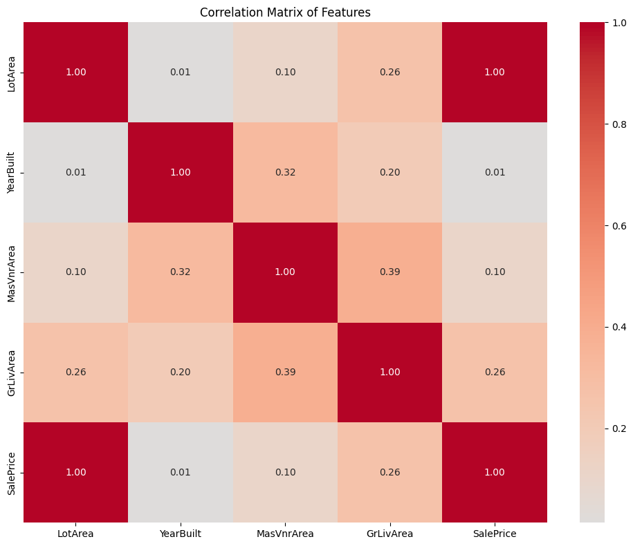

```python
# We will create a correlation matrix of all the features that we have used.
plt.figure(figsize=(10, 8))
sns.heatmap(correlation_matrix, annot=True, fmt='.2f', cmap='coolwarm', center=0)
plt.title('Correlation Matrix of Features')
plt.tight_layout()
plt.show()
```

```python
# We can create and fit the scaler.
scaler = StandardScaler()
X_train_scaled = scaler.fit_transform(X_train)
X_test_scaled = scaler.fit_transform(X_test)

# We should define the feature columns.
feature_columns = x.columns

# We will convert this back to the DataFrame.
X_train_scaled = pd.DataFrame(X_train_scaled, columns=feature_columns, index=X_train.index)
X_test_scaled = pd.DataFrame(X_test_scaled, columns=feature_columns, index=X_test.index)
```

```python
# Most importantly, we will create and train the model.
model = LinearRegression()
model.fit(X_train_scaled, y_train)
```

```
LinearRegression()
```

```python
# We can extract and display the coefficients for four of our features.
intercept = model.intercept_
coefficients = model.coef_

coef_df = pd.DataFrame({
    'Feature': feature_columns,
    'Coefficient': coefficients
}).sort_values('Coefficient', key=abs, ascending=False)

print(f"Intercept: {intercept:.4f}")
print("\nCoefficients (sorted by absolute value):")
print(coef_df)
```

```
Intercept: 179769.6796

Coefficients (sorted by absolute value):
      Feature   Coefficient
3   GrLivArea  40162.260768
1   YearBuilt  28745.515987
2  MasVnrArea  11087.790641
0     LotArea   7812.452734
```

```python
# We can combine these coefficients to form the entire equation for our linear
# regression.
print(f"Predicted Housing Price = {intercept:.4f} + {coefficients[0]:.4f}(Lot Area) + {coefficients[1]:.4f}(YearBuilt) + {coefficients[2]:.4f}(MasVnrArea) + {coefficients[3]:.4f}(GrLivArea)")
```

```
Predicted Housing Price = 179769.6796 + 7812.4527(Lot Area) + 28745.5160(YearBuilt) + 11087.7906(MasVnrArea) + 40162.2608(GrLivArea)
```

```python
# We will look at the meaning of each coefficient within this context.
print("Interpretation of all our coefficients (on scaled data): \n")

print(f"Intercept: ${intercept:.2f}")
print("  Average sale price when all explanatory variables are at their mean values.\n")

for feature, coef in zip(x.columns, coefficients):
    print(f"{feature}: ${coef:.2f}")
    print(f"  When {feature} increases by 1 standard deviation,")
    print(f"  the sale price increases by ${coef:.2f}k (about {coef*1000:.0f} units),")
    print(f"  holding other explanatory variables constant.\n")
```

```
Interpretation of all our coefficients (on scaled data):

Intercept: $179769.68
  Average sale price when all explanatory variables are at their mean values.

LotArea: $7812.45
  When LotArea increases by 1 standard deviation,
  the sale price increases by $7812.45k (about 7812453 units),
  holding other explanatory variables constant.

YearBuilt: $28745.52
  When YearBuilt increases by 1 standard deviation,
  the sale price increases by $28745.52k (about 28745516 units),
  holding other explanatory variables constant.

MasVnrArea: $11087.79
  When MasVnrArea increases by 1 standard deviation,
  the sale price increases by $11087.79k (about 11087791 units),
  holding other explanatory variables constant.

GrLivArea: $40162.26
  When GrLivArea increases by 1 standard deviation,
  the sale price increases by $40162.26k (about 40162261 units),
  holding other explanatory variables constant.
```

```python
# Now, we can evaluate our new multiple regression model by checking the
# performance of the training set.
y_train_pred = model.predict(X_train_scaled)
r2_train = r2_score(y_train, y_train_pred)
mse_train = mean_squared_error(y_train, y_train_pred)
rmse_train = np.sqrt(mse_train)

print("Training Set Performance")
print(f"  R-Squared Value: {r2_train:.4f}")
print(f"  Mean Squared Error: {mse_train:.4f}")
print(f"  Root Mean Squared Error: {rmse_train:.4f}")
```

```
Training Set Performance
  R-Squared Value: 0.6669
  Mean Squared Error: 1933643512.4422
  Root Mean Squared Error: 43973.2136
```

```python
# We can also do the same with the performance of the test set.
y_test_pred = model.predict(X_test_scaled)
r2_test = r2_score(y_test, y_test_pred)
mse_test = mean_squared_error(y_test, y_test_pred)
rmse_test = np.sqrt(mse_test)

print("Test Set Performance")
print(f"  R-Squared Value: {r2_test:.4f}")
print(f"  Mean Squared Error: {mse_test:.4f}")
print(f"  Root Mean Squared Error: {rmse_test:.4f}\n")
```

```
Test Set Performance
  R-Squared Value: 0.6833
  Mean Squared Error: 2588277207.6630
  Root Mean Squared Error: 50875.1138
```

**Application:**  
Consider using our multiple linear regression model to predict the sale price of a house which...

- has a lot size of 1,000 square feet,
- was built in 1987,
- has a masonry veneer area of 100 square feet, and
- has a ground living area of 2,000 square feet.  
  According to this given data and our regression model, the predicted sale price is about $219,454.33.

```python
# We can apply this example to our regression model.
prediction_x = pd.DataFrame({
    'LotArea': [1000],
    'YearBuilt': [1987],
    'MasVnrArea': [100],
    'GrLivArea': [2000]
})
prediction_x_scaled = scaler.transform(prediction_x)
prediction_x_scaled = pd.DataFrame(prediction_x_scaled, columns = x.columns)
prediction_y = model.predict(prediction_x_scaled)
print(f"Predicted Sale Price: ${prediction_y[0]:.2f}")
```

```
Predicted Sale Price: $219454.33
```

```python
# We can also manually make sure that this prediction is true.
manual_prediction = intercept + np.sum(coefficients * prediction_x_scaled.values[0])
print(f"Manual calculation: ${manual_prediction:.2f}")
print(f"Model prediction: ${prediction_y[0]:.2f}")
print(f"Match: {np.isclose(manual_prediction, prediction_y[0])}")
```

```
Manual calculation: $219454.33
Model prediction: $219454.33
Match: True
```

# **Part 6 – Model Limitations and Ethical Concerns**

Even though a linear regression model has been constructed to predict the price of housing, it inherently has its own limits.

In the social sciences and mathematics, models are inherently a simplified structure of the real world around them. For example, in the context of this model, it uses various features of a house to predict the pricing of a house. Therefore, models inherently have the limitation of selecting a variables of an object to characterize an entire object. This is simply the epistemic problem of models.

As our goal was to predict the price of housing using the given dataset, it attributed features (such as lot size, year built, masonry veneer area, and ground living area) a strong or weak regression parameter based on the association between the given feature and the outcome (in this case, housing price). However, are there other features of houses in Iowa that may influence the price of a house more than the selected characteristics? This leads to another problem of this model: the problem of data collection. When data collectors gathered the data about housing in Iowa, they intentionally looked for and measured particular features of a house that seemed to be important to houses. Therefore, it is important to account for surveyors bias towards data collection as a limitation for models.

Another additional issue that can emerge within regression modeling is the problem of inaccurate inferences. Although there is a large sample of houses from Ames, Iowa, there will still be a gap between the sample data and the population data. Regression modeling is a form of inferential statistics, where there is an attempt to predict population parameters about housing (in this instance, housing price) using a small sample of data. This is a solid dataset with more than 1,000 houses used as rows. Although this can be close to a representative population of housing in this area, there is always a chance that it may be inaccurate. This presents itself as a limitation.

What about the ethical concerns about modeling data? Two issues that can emerge from modeling data like this. For one, the usage of predictive/inferential statistics in housing can be used in an unethical manner. As the United States faces a housing crisis, larger companies may use models such as these to predict where profitability may lie within housing. This denies individuals who are starting their lives the potential ownership of housing. A form of information disymmetry emerges: larger companies use large data for profits, while individuals are uncertain about the information about housing on the market.

Another issue may emerge within modeling data, which is privacy concerns. Companies that large amounts of data, including ones about housing, may go against the interests of those who live within these houses. There is no easy way to delete data that is out online. Therefore, questions about privacy and safety can emerge quickly when someone has access to data about any particular house.

Despite these limitations and ethical issues, modeling data may allow for data scientists to gain an understanding of phenomena when there is a large amount of uncertainty. In other words, data scientists can extract the signal from the noise. The practice of modeling housing data simply through regression can allow us to understand which parameters can predict the price of housing.

```python
# Convert this notebook to HTML.
!jupyter nbconvert --to html "/content/drive/MyDrive/Foundations_of_Data_Science/Projects/MATH237Project1.ipynb" --output project
```

```
[NbConvertApp] Converting notebook /content/drive/MyDrive/Foundations_of_Data_Science/Projects/MATH237Project1.ipynb to html
[NbConvertApp] WARNING | Alternative text is missing on 4 image(s).
[NbConvertApp] Writing 991274 bytes to /content/drive/MyDrive/Foundations_of_Data_Science/Projects/project.html
```